# 4 Village-level headline results

```r
pacman::p_load(
  dplyr,
  readr,
  tidyr,
  glue,
  sf,
  tidyverse,
  viridis,
  fixest,
  janitor,
  broom,
  car,
  modelsummary,
  survey,
  here
)
```

## 4.1 People using DSW/ILC water points

### 4.1.1 Prepare data

To calculate the number of people using water points with DSW or ILC, we use self-reported data from the household census on what is the household’s primary water point. This information is combined with data from the water point census to determine whether these water points are served by DSW or ILC.

We start by restricting the household census data to households using water points with DSW or ILC located inside the sampled villages. We also exclude households using ILC in Uganda because we did not design the survey to be representative of this population.

```r
users_data <-
  hh_census %>%
  dplyr::filter(
    wp_intervention_type != "Non-program",
    wp_invillage,
    !(sample_group != "ILC" & wp_intervention == "ILC")
  )
```

The relevant variable to calculate the number of people using water points with DSW or ILC is the number of people living in households that report their primary water source has DSW or ILC. Due to a coding mistake, this variable was not collected in the first few days of data collection in Uganda. Therefore, we need to impute values for the households where this information is missing.

```r
users_data %>%
  dplyr::filter(!is.na(wp_intervention_type), is.na(hh_members)) %>%
  tabyl(date, country) %>%
  adorn_totals()
```

```
##        date Uganda
##  2025-07-02      4
##  2025-07-03     35
##  2025-07-04      3
##  2025-07-07     13
##  2025-07-08    255
##  2025-07-09    158
##  2025-07-10     28
##  2025-07-11     37
##  2025-07-14    130
##  2025-07-15     21
##  2025-07-16      1
##       Total    685
```

There are 12 villages in Uganda with no observations for this variable, so we cannot impute it as the village average. Therefore, we impute it are the sample group level.

```r
users_data <-
  users_data %>%
  group_by(country, sample_group) %>%
  mutate(
    hh_members = if_else(
      !is.na(hh_members),
      hh_members,
      mean(hh_members, na.rm = TRUE)
    )
  )
```

To account for the villages where all the water points with ILC were out of order, we add them to the data, but with zero households using water points with ILC.

```r
users_data <-
  users_data %>%
  full_join(
    village_intervention %>%
      select(village_id, country, sample_group, wp_intervention)
  ) %>%
  mutate(
    hh_members = replace_na(hh_members, 0)
  )
```

Since the unit of reference for our analysis is the village, we calculate the number of people whose primary water source has DSW or ILC by adding the number of household members across all such households in a village.

```r
users_village <-
  users_data %>%
  group_by(village_id, country, sample_group, wp_intervention) %>%
  summarise(
    response_rate = unique(response_rate),
    hhs = n(),
    users = sum(hh_members)
  ) %>%
  mutate(
    users_increased = users/response_rate
  )
```

[output not shown]

To scale to the country level, we combine this data with the number of sampled villages and the number of villages in the admin data per group.

```r
users_village <-
  users_village %>%
  left_join(sample_sizes) %>%
  group_by(country, sample_group) %>%
  mutate(
    weight = n_villages/n_distinct(village_id)
  ) %>%
  ungroup
```

```r
users_village %>%
  dplyr::filter(hhs == 1)
```

```
## # A tibble: 89 × 12
##    village_id country sample_group wp_intervention response_rate   hhs users
##    <chr>      <chr>   <ord>        <chr>                   <dbl> <int> <dbl>
##  1 1041204010 Uganda  ILC          DSW                        NA     1     0
##  2 1041204010 Uganda  ILC          ILC                        NA     1     0
##  3 1051401001 Uganda  ILC          DSW                        NA     1     0
##  4 1051401001 Uganda  ILC          ILC                        NA     1     0
##  5 1080102001 Uganda  ILC          DSW                        NA     1     0
##  6 1080102001 Uganda  ILC          ILC                        NA     1     0
##  7 1080501001 Uganda  ILC          DSW                        NA     1     0
##  8 1080501001 Uganda  ILC          ILC                        NA     1     0
##  9 1090104009 Uganda  ILC          DSW                        NA     1     0
## 10 1090104009 Uganda  ILC          ILC                        NA     1     0
## # ℹ 79 more rows
## # ℹ 5 more variables: users_increased <dbl>, n_villages <int>,
## #   visited_villages <int>, sampled_villages <int>, weight <dbl>
```

```r
users_village <-
  users_village %>%
  dplyr::filter(hhs > 1)
```

### 4.1.2 Sanity check

Here we just calculate the total number of people without CIs. The point estimate should be the same as the one calculated with a canned function.

```r
users_village %>%
  group_by(country, sample_group, wp_intervention) %>%
  summarise(
    n = n_distinct(village_id),
    hhs = mean(hhs),
    av_people = mean(users),
    av_people_non = mean(users_increased),
    sampled_villages = unique(sampled_villages),
    vil_weight = n/sampled_villages,
    group_weight = unique(n_villages)
  ) %>%
  mutate(
    total_people = round(av_people * group_weight * vil_weight),
    total_people_non = round(av_people_non * group_weight * vil_weight)
  )
```

```
## # A tibble: 6 × 12
## # Groups:   country, sample_group [5]
##   country sample_group wp_intervention     n   hhs av_people av_people_non
##   <chr>   <ord>        <chr>           <int> <dbl>     <dbl>         <dbl>
## 1 Malawi  Footprint    DSW                27  47.1      208.          217.
## 2 Malawi  Expansion    DSW                28  76.5      363.          365.
## 3 Malawi  ILC          DSW                24  70.9      299.          301.
## 4 Malawi  ILC          ILC                28  42.5      191.          195.
## 5 Uganda  Footprint    DSW                30  49.3      265.          286.
## 6 Uganda  Expansion    DSW                30 116.       621.          722.
## # ℹ 5 more variables: sampled_villages <int>, vil_weight <dbl>,
## #   group_weight <int>, total_people <dbl>, total_people_non <dbl>
```

### 4.1.3 Final numbers

We the total number of users per sample group and the confidence intervals around this number using the package `survey` to adjust standard errors for the survey design.

#### 4.1.3.1 By program and sample group

```r
people_per_group <-
  map(
    users_village %>%
      group_by(country, sample_group, wp_intervention) %>%
      group_split(),
    ~ total_ci(
        var = "users_increased",
        design = svydesign(
          id = ~ village_id,
          data = .x,
          weights = ~ weight
        )
      ) %>%
      mutate(
        country = .x %>% pull(country) %>% unique,
        sample_group = .x %>% pull(sample_group) %>% unique,
        wp_intervention = .x %>% pull(wp_intervention) %>% unique,
        villages = .x %>% pull(village_id) %>% n_distinct,
        households = .x %>% pull(hhs) %>% mean,
        weight = .x %>% pull(weight) %>% unique
      )
  ) %>%
  bind_rows() %>%
  select(
    country, sample_group, wp_intervention,
    outcome,
    villages, weight,
    everything()
  ) %>%
  arrange(outcome)

people_per_group
```

```
##   country sample_group wp_intervention         outcome villages    weight
## 1  Malawi    Footprint             DSW users_increased       27  41.46429
## 2  Malawi    Expansion             DSW users_increased       28 171.75000
## 3  Malawi          ILC             DSW users_increased       24  13.27083
## 4  Malawi          ILC             ILC users_increased       28  13.27083
## 5  Uganda    Footprint             DSW users_increased       30 105.76667
## 6  Uganda    Expansion             DSW users_increased       30 133.73333
##        total        se         lb         ub households
## 1  242715.55  34298.61  175491.50  309939.59   47.14815
## 2 1752944.50 301860.50 1161308.79 2344580.21   76.46429
## 3   95998.09  17111.60   62459.96  129536.21   70.91667
## 4   72326.63  12894.19   47054.49   97598.77   42.53571
## 5  907708.20 127724.20  657373.37 1158043.03   49.30000
## 6 2895777.68 380425.48 2150157.44 3641397.92  115.56667
```

#### 4.1.3.2 By program

```r
people_per_country <-
  map(
    users_village %>%
      group_by(country, wp_intervention) %>%
      group_split(),
    ~ total_ci(
        var = "users_increased",
        design = svydesign(
          id = ~ village_id,
          data = .x,
          weights = ~ weight
        )
      ) %>%
      mutate(
        country = .x %>% pull(country) %>% unique,
        wp_intervention = .x %>% pull(wp_intervention) %>% unique,
        villages = .x %>% pull(village_id) %>% n_distinct,
        hhs = .x %>% pull(hhs) %>% sum,
        pop = .x %>% pull(n_villages) %>% unique %>% sum
      )
  ) %>%
  bind_rows() %>%
  select(
    country, wp_intervention,
    outcome,
    villages,
    everything()
  ) %>%
  arrange(outcome)

people_per_country
```

```
##   country wp_intervention         outcome villages      total        se
## 1  Malawi             DSW users_increased       79 2091658.13 384814.82
## 2  Malawi             ILC users_increased       28   72326.63  12894.19
## 3  Uganda             DSW users_increased       60 3803485.88 474655.40
##           lb         ub  hhs  pop
## 1 1337434.95 2845881.32 5116 6607
## 2   47054.49   97598.77 1191  637
## 3 2873178.39 4733793.37 4946 7185
```

### 4.1.4 Sensitivity checks

#### 4.1.4.1 Don’t correct for non-responses

```r
users_vil_responseonly <-
  map(
    users_village %>%
      group_by(country, wp_intervention) %>%
      group_split(),
    ~ total_ci(
        var = "users",
        design = svydesign(
          id = ~ village_id,
          data = .x,
          weights = ~ weight
        )
      ) %>%
      mutate(
        country = .x %>% pull(country) %>% unique,
        wp_intervention = .x %>% pull(wp_intervention) %>% unique,
        villages = .x %>% pull(village_id) %>% n_distinct
      )
  ) %>%
  bind_rows() %>%
  select(
    country, wp_intervention,
    outcome,
    villages,
    everything()
  ) %>%
  arrange(outcome)
```

#### 4.1.4.2 Include households using water points outside of the village

```r
users_outside <-
  hh_census %>%
  dplyr::filter(
    !is.na(wp_intervention),
    !(sample_group != "ILC" & wp_intervention == "ILC")
  ) %>%
  group_by(country, sample_group) %>%
  mutate(
    hh_members = if_else(
      !is.na(hh_members),
      hh_members,
      mean(hh_members, na.rm = TRUE)
    )
  ) %>%
  full_join(
    village_intervention %>%
      select(village_id, country, sample_group, wp_intervention)
  ) %>%
  mutate(
    hh_members = replace_na(hh_members, 0)
  ) %>%
  group_by(village_id, country, sample_group, wp_intervention) %>%
  summarise(
    response_rate = unique(response_rate),
    hhs = n(),
    users = sum(hh_members)
  ) %>%
  mutate(
    users_increased = users/response_rate
  ) %>%
  left_join(sample_sizes) %>%
  group_by(country, sample_group) %>%
  mutate(
    weight = n_villages/n_distinct(village_id)
  ) %>%
  dplyr::filter(hhs > 1) %>%
  ungroup
```

[output not shown]

```r
users_vil_outside <-
  map(
    users_outside %>%
      group_by(country, wp_intervention) %>%
      group_split(),
    ~ total_ci(
        var = "users_increased",
        design = svydesign(
          id = ~ village_id,
          data = .x,
          weights = ~ weight
        )
      ) %>%
      mutate(
        country = .x %>% pull(country) %>% unique,
        wp_intervention = .x %>% pull(wp_intervention) %>% unique,
        villages = .x %>% pull(village_id) %>% n_distinct
      )
  ) %>%
  bind_rows() %>%
  select(
    country, wp_intervention,
    outcome,
    villages,
    everything()
  ) %>%
  arrange(outcome)
```

#### 4.1.4.3 Exclude households living outside of village boundaries

```r
users_vilboundary <-
  hh_census %>%
  dplyr::filter(
    !is.na(wp_intervention),
    wp_invillage,
    inclusion == "Within village boundaries",
    !(sample_group != "ILC" & wp_intervention == "ILC")
  ) %>%
  group_by(country, sample_group) %>%
  mutate(
    hh_members = if_else(
      !is.na(hh_members),
      hh_members,
      mean(hh_members, na.rm = TRUE)
    )
  ) %>%
  full_join(
    village_intervention %>%
      select(village_id, country, sample_group, wp_intervention)
  ) %>%
  mutate(
    hh_members = replace_na(hh_members, 0)
  ) %>%
  group_by(village_id, country, sample_group, wp_intervention) %>%
  summarise(
    response_rate = unique(response_rate),
    hhs = n(),
    users = sum(hh_members)
  ) %>%
  mutate(
    users_increased = users/response_rate
  ) %>%
  left_join(sample_sizes) %>%
  group_by(country, sample_group) %>%
  mutate(
    weight = n_villages/n_distinct(village_id)
  ) %>%
  dplyr::filter(hhs > 1) %>%
  ungroup
```

[output not shown]

```r
users_vil_boundary <-
  map(
    users_vilboundary %>%
      group_by(country, wp_intervention) %>%
      group_split(),
    ~ total_ci(
        var = "users_increased",
        design = svydesign(
          id = ~ village_id,
          data = .x,
          weights = ~ weight
        )
      ) %>%
      mutate(
        country = .x %>% pull(country) %>% unique,
        wp_intervention = .x %>% pull(wp_intervention) %>% unique,
        villages = .x %>% pull(village_id) %>% n_distinct
      )
  ) %>%
  bind_rows() %>%
  select(
    country, wp_intervention,
    outcome,
    villages,
    everything()
  ) %>%
  arrange(outcome)
```

#### 4.1.4.4 Correct for missed water points

```r
users_vil_misspoints <-
  map(
    users_vilboundary %>%
      mutate(
        users_increased =
          case_when(
            wp_intervention == "DSW" ~ users_increased * 1.12,
            wp_intervention == "ILC" ~ users_increased * 1.05
          )
      ) %>%
      dplyr::filter(country == "Malawi") %>%
      group_by(country, wp_intervention) %>%
      group_split(),
    ~ total_ci(
        var = "users_increased",
        design = svydesign(
          id = ~ village_id,
          data = .x,
          weights = ~ weight
        )
      ) %>%
      mutate(
        country = .x %>% pull(country) %>% unique,
        wp_intervention = .x %>% pull(wp_intervention) %>% unique,
        villages = .x %>% pull(village_id) %>% n_distinct
      )
  ) %>%
  bind_rows() %>%
  select(
    country, wp_intervention,
    outcome,
    villages,
    everything()
  ) %>%
  arrange(outcome)
```

#### 4.1.4.5 Don’t correct for non-functional ILC

```r
users_func <-
  hh_census %>%
  dplyr::filter(
    !is.na(wp_intervention),
    wp_invillage,
    !(sample_group != "ILC" & wp_intervention == "ILC")
  ) %>%
  group_by(country, sample_group) %>%
  mutate(
    hh_members = if_else(
      !is.na(hh_members),
      hh_members,
      mean(hh_members, na.rm = TRUE)
    )
  ) %>%
  group_by(village_id, country, sample_group, wp_intervention) %>%
  summarise(
    response_rate = unique(response_rate),
    hhs = n(),
    users = sum(hh_members)
  ) %>%
  mutate(
    users_increased = users/response_rate
  ) %>%
  left_join(sample_sizes) %>%
  group_by(country, sample_group) %>%
  mutate(
    weight = n_villages/n_distinct(village_id)
  ) %>%
  dplyr::filter(hhs > 1) %>%
  ungroup
```

[output not shown]

```r
users_vil_func <-
  map(
    users_func %>%
      group_by(country, wp_intervention) %>%
      group_split(),
    ~ total_ci(
        var = "users_increased",
        design = svydesign(
          id = ~ village_id,
          data = .x,
          weights = ~ weight
        )
      ) %>%
      mutate(
        country = .x %>% pull(country) %>% unique,
        wp_intervention = .x %>% pull(wp_intervention) %>% unique,
        villages = .x %>% pull(village_id) %>% n_distinct
      )
  ) %>%
  bind_rows() %>%
  select(
    country, wp_intervention,
    outcome,
    villages,
    everything()
  ) %>%
  arrange(outcome)
```

#### 4.1.4.6 Use raw FO reports

```r
users_fo <-
  hh_census %>%
  mutate(wp_intervention = intervention_fo) %>%
  dplyr::filter(
    !is.na(wp_intervention),
    wp_invillage,
    !(sample_group != "ILC" & wp_intervention == "ILC")
  ) %>%
  group_by(country, sample_group) %>%
  mutate(
    hh_members = if_else(
      !is.na(hh_members),
      hh_members,
      mean(hh_members, na.rm = TRUE)
    )
  ) %>%
  full_join(
    village_intervention %>%
      select(village_id, country, sample_group, wp_intervention)
  ) %>%
  mutate(
    hh_members = replace_na(hh_members, 0)
  ) %>%
  group_by(village_id, country, sample_group, wp_intervention) %>%
  summarise(
    response_rate = unique(response_rate),
    hhs = n(),
    users = sum(hh_members)
  ) %>%
  mutate(
    users_increased = users/response_rate
  ) %>%
  left_join(sample_sizes) %>%
  group_by(country, sample_group) %>%
  mutate(
    weight = n_villages/n_distinct(village_id)
  ) %>%
  dplyr::filter(hhs > 1) %>%
  ungroup
```

[output not shown]

```r
users_vil_fo <-
  map(
    users_fo %>%
      group_by(country, wp_intervention) %>%
      group_split(),
    ~ total_ci(
        var = "users_increased",
        design = svydesign(
          id = ~ village_id,
          data = .x,
          weights = ~ weight
        )
      ) %>%
      mutate(
        country = .x %>% pull(country) %>% unique,
        wp_intervention = .x %>% pull(wp_intervention) %>% unique,
        villages = .x %>% pull(village_id) %>% n_distinct
      )
  ) %>%
  bind_rows() %>%
  select(
    country, wp_intervention,
    outcome,
    villages,
    everything()
  ) %>%
  arrange(outcome)
```

#### 4.1.4.7 Plot

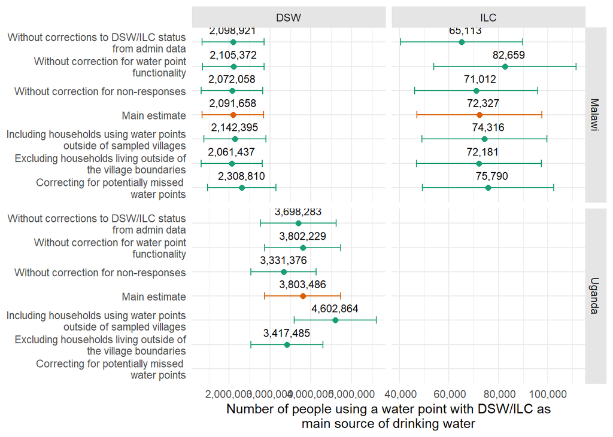

```r
plot_data <-
  list(
    "Main estimate" = people_per_country,
    "Including households using water points\noutside of sampled villages" = users_vil_outside,
    "Excluding households living outside of\nthe village boundaries" = users_vil_boundary,
    "Without correction for non-responses" = users_vil_responseonly,
    "Without corrections to DSW/ILC status\nfrom admin data" = users_vil_fo,
    "Without correction for water point\nfunctionality" = users_vil_func,
    "Correcting for potentially missed \nwater points" = users_vil_misspoints
  ) %>%
    map(
      ~ .x %>%
        select(country, wp_intervention, outcome, total, ub, lb)
    ) %>%
    bind_rows(.id = "label") %>%
    mutate(
      main = label == "Main estimate"
    ) %>%
    dplyr::filter(wp_intervention != "Non-program")

plot_data %>%
  ggplot(
    aes(
      y = label,
      xmin = lb,
      xmax = ub,
      x = total,
      label = format(round(total), big.mark = ","),
      color = main
    )
  ) +
  geom_errorbar(width = .3) +
  geom_point(size = 2) +
  geom_text(
    color = "black",
    size = 3,
    vjust = -1
  ) +
  facet_grid(
    country ~ wp_intervention,
    scales = "free_x"
  ) +
  scale_x_continuous(labels = ~ format(., big.mark = ",", scientific = FALSE)) +
  scale_fill_brewer(palette = "Dark2") +
  scale_color_brewer(palette = "Dark2") +
  theme +
  scale_x_continuous(labels = ~ format(., big.mark = ",", scientific = FALSE)) +
  theme(legend.position = "none") +
  labs(
    y = NULL,
    x = "Number of people using a water point with DSW/ILC as\nmain source of drinking water"
  )
```

#### 4.1.4.8 Save Plot

```r
ggplot2::ggsave(
  filename = "output/graphs/users-vil.png",
  plot     = ggplot2::last_plot(),
  width    = 8,
  height   = 4.5,
  units    = "in",
  dpi      = 300
)
```

## 4.2 Chlorine detection rates

### 4.2.1 Prepare data

```r
chlorination_data <-
  hh_survey %>%
  dplyr::filter(
    wp_intervention_type != "Non-program",
    !(sample_group != "ILC" & wp_intervention == "ILC")
  ) %>%
  ungroup %>%
  left_join(
    hh_census %>%
      group_by(
        village_id,
        wp_intervention
      ) %>%
      summarise(pop_users = n_distinct(household_id)/unique(response_rate))
  ) %>%
  group_by(village_id) %>%
  mutate(
    # This is if we weigh each village equally
    weight_equal = n_distinct(household_id)/20,
    # This is if we apply sampling weights
    weight_users = n_distinct(household_id)/pop_users,
  ) %>%
  ungroup
```

### 4.2.2 Sanity check

```r
chlorination_data %>%
  group_by(village_id, sample_group, wp_intervention_type, country) %>%
  summarise(
    across(
      c("disctcr_02", "discfcr_02"),
      ~ mean(., na.rm = TRUE)
    ),
    hhs = n()
  ) %>%
  group_by(country, sample_group, wp_intervention_type) %>%
  summarise(
    across(
      c("disctcr_02", "discfcr_02"),
      ~ mean(., na.rm = TRUE)
    ),
    hhs = sum(hhs),
    villages = n()
  )
```

```
## # A tibble: 7 × 7
## # Groups:   country, sample_group [5]
##   country sample_group wp_intervention_type disctcr_02 discfcr_02   hhs villages
##   <chr>   <ord>        <fct>                     <dbl>      <dbl> <int>    <int>
## 1 Malawi  Footprint    DSW                       0.296      0.209   442       25
## 2 Malawi  Expansion    DSW                       0.264      0.210   520       28
## 3 Malawi  ILC          DSW                       0.239      0.207   331       25
## 4 Malawi  ILC          ILC water collectio…      0.342      0.137   308       23
## 5 Malawi  ILC          ILC water point           0.479      0.381    60       10
## 6 Uganda  Footprint    DSW                       0.303      0.207   547       30
## 7 Uganda  Expansion    DSW                       0.319      0.204   588       30
```

```r
chlorination_data %>%
  group_by(country, sample_group, wp_intervention_type) %>%
  summarise(
    across(
      c("disctcr_02", "discfcr_02"),
      ~ mean(., na.rm = TRUE)
    ),
    hhs = n(),
    villages = n_distinct(village_id)
  )
```

```
## # A tibble: 7 × 7
## # Groups:   country, sample_group [5]
##   country sample_group wp_intervention_type disctcr_02 discfcr_02   hhs villages
##   <chr>   <ord>        <fct>                     <dbl>      <dbl> <int>    <int>
## 1 Malawi  Footprint    DSW                       0.301      0.216   442       25
## 2 Malawi  Expansion    DSW                       0.270      0.217   520       28
## 3 Malawi  ILC          DSW                       0.206      0.181   331       25
## 4 Malawi  ILC          ILC water collectio…      0.282      0.130   308       23
## 5 Malawi  ILC          ILC water point           0.451      0.255    60       10
## 6 Uganda  Footprint    DSW                       0.280      0.180   547       30
## 7 Uganda  Expansion    DSW                       0.327      0.212   588       30
```

### 4.2.3 Final numbers

#### 4.2.3.1 Separating ILC WP and ILC WCP

```r
cl_village_noweights_ilc <-
  chlorination_data %>%
  group_by(country, sample_group, wp_intervention_type) %>%
  group_split %>%
  map(
    ~ mean_cis(
        outcomes = c("discfcr_02", "disctcr_02"),
        design = svydesign(
          id = ~ village_id + wp_id,      # PSU (here: villages)
          data = .,
          nest = TRUE
        )
    ) %>%
      mutate(
        country = .x %>% pull(country) %>% unique,
        sample_group = .x %>% pull(sample_group) %>% unique,
        wp_intervention = .x %>% pull(wp_intervention_type) %>% unique,
        hhs = .x %>% pull(household_id) %>% n_distinct,
        villages = .x %>% pull(village_id) %>% n_distinct,
      )
  ) %>%
  bind_rows %>%
  select(country, sample_group, wp_intervention, outcome, everything()) %>%
  arrange(desc(outcome))
```

#### 4.2.3.2 By sample group and program

```r
cl_village_noweights_samplegroup <-
  chlorination_data %>%
  group_by(country, sample_group, wp_intervention) %>%
  group_split %>%
  map(
    ~ mean_cis(
        outcomes = c("discfcr_02", "disctcr_02"),
        design = svydesign(
          id = ~ village_id + wp_id,      # PSU (here: villages)
          data = .,
          nest = TRUE
        )
    ) %>%
      mutate(
        country = .x %>% pull(country) %>% unique,
        sample_group = .x %>% pull(sample_group) %>% unique,
        wp_intervention = .x %>% pull(wp_intervention) %>% unique,
        hhs = .x %>% pull(household_id) %>% n_distinct,
        villages = .x %>% pull(village_id) %>% n_distinct,
      )
  ) %>%
  bind_rows %>%
  select(country, sample_group, wp_intervention, outcome, everything()) %>%
  arrange(desc(outcome))
```

#### 4.2.3.3 Check program differences

Before we combine observations in different sample groups, we want to make sure that chlorination rates are not different across them

```r
feols(
  disctcr_02 ~ sample_group,
  cluster = ~ village_id,
  data = chlorination_data %>%
    dplyr::filter(country == "Uganda")
) %>%
  summary
```

```
## NOTE: 146 observations removed because of NA values (LHS: 146).
```

```
## The variable 'sample_group.Q' has been removed because of collinearity (see $collin.var).
```

```
## OLS estimation, Dep. Var.: disctcr_02
## Observations: 989
## Standard-errors: Clustered (village_id)
##                Estimate Std. Error  t value   Pr(>|t|)
## (Intercept)    0.327451   0.036975 8.856108 1.9858e-12 ***
## sample_group.L 0.067460   0.080521 0.837799 4.0552e-01
## ... 1 variable was removed because of collinearity (sample_group.Q)
## ---
## Signif. codes:  0 '***' 0.001 '**' 0.01 '*' 0.05 '.' 0.1 ' ' 1
## RMSE: 0.459513   Adj. R2: 0.001674
```

```r
feols(
  disctcr_02 ~ sample_group,
  cluster = ~ village_id,
  data = chlorination_data %>%
    dplyr::filter(country == "Malawi")
) %>%
  summary
```

```
## NOTE: 41 observations removed because of NA values (LHS: 41).
```

```
## OLS estimation, Dep. Var.: disctcr_02
## Observations: 1,620
## Standard-errors: Clustered (village_id)
##                 Estimate Std. Error   t value  Pr(>|t|)
## (Intercept)     0.276408   0.025430 10.869343 < 2.2e-16 ***
## sample_group.L -0.030127   0.040913 -0.736365   0.46332
## sample_group.Q  0.008422   0.046971  0.179312   0.85807
## ---
## Signif. codes:  0 '***' 0.001 '**' 0.01 '*' 0.05 '.' 0.1 ' ' 1
## RMSE: 0.445393   Adj. R2: 2.91e-4
```

```r
model <-
  feols(
    disctcr_02 ~ sample_group,
    cluster = ~ village_id,
    data = chlorination_data %>%
      dplyr::filter(
        country == "Malawi"
      )
  )
```

```
## NOTE: 41 observations removed because of NA values (LHS: 41).
```

```r
summary(model)
```

```
## OLS estimation, Dep. Var.: disctcr_02
## Observations: 1,620
## Standard-errors: Clustered (village_id)
##                 Estimate Std. Error   t value  Pr(>|t|)
## (Intercept)     0.276408   0.025430 10.869343 < 2.2e-16 ***
## sample_group.L -0.030127   0.040913 -0.736365   0.46332
## sample_group.Q  0.008422   0.046971  0.179312   0.85807
## ---
## Signif. codes:  0 '***' 0.001 '**' 0.01 '*' 0.05 '.' 0.1 ' ' 1
## RMSE: 0.445393   Adj. R2: 2.91e-4
```

```r
fitstat(model, type = "f")
```

```
## F-test: stat = 0.072596, p = 0.930028, on 2 and 95 DoF.
```

```r
feols(
  discfcr_02 ~ wp_intervention_type,
  cluster = ~ village_id,
  data = chlorination_data %>%
    dplyr::filter(
      country == "Malawi",
      wp_intervention == "ILC"
    )
) %>%
  summary
```

```
## NOTE: 16 observations removed because of NA values (LHS: 16).
```

```
## The variable 'wp_intervention_typeILC water point' has been removed because of collinearity (see $collin.var).
```

```
## OLS estimation, Dep. Var.: discfcr_02
## Observations: 352
## Standard-errors: Clustered (village_id)
##                                                 Estimate Std. Error  t value
## (Intercept)                                     0.254902   0.067692  3.76564
## wp_intervention_typeILC water collection point -0.125334   0.071920 -1.74269
##                                                  Pr(>|t|)
## (Intercept)                                    0.00085888 ***
## wp_intervention_typeILC water collection point 0.09320598 .
## ... 1 variable was removed because of collinearity (wp_intervention_typeILC water point)
## ---
## Signif. codes:  0 '***' 0.001 '**' 0.01 '*' 0.05 '.' 0.1 ' ' 1
## RMSE: 0.352076   Adj. R2: 0.012645
```

#### 4.2.3.4 By program

```r
cl_village_noweights_country <-
  chlorination_data %>%
  group_by(country, wp_intervention) %>%
  group_split() %>%
  map(
    ~ mean_cis(
        outcomes = c("discfcr_02", "disctcr_02"),
        design = svydesign(
          id = ~ village_id + wp_id,      # PSU (here: villages)
          data = .,
          nest = TRUE,
          strata = ~ sample_group
        )
    ) %>%
      mutate(
        country = .x %>% pull(country) %>% unique,
        wp_intervention = .x %>% pull(wp_intervention) %>% unique,
        hhs = .x %>% pull(household_id) %>% n_distinct,
        villages = .x %>% pull(village_id) %>% n_distinct,
      )
  ) %>%
  bind_rows() %>%
  select(country, wp_intervention, outcome, everything()) %>%
  arrange(desc(outcome))
```

### 4.2.4 Sensitivity checks

#### 4.2.4.1 Assinging no chlorination if not tested

```r
cl_village_nottested <-
  chlorination_data %>%
  mutate(
    across(
      c("discfcr_02", "disctcr_02"),
      ~ case_when(
        !water_sample ~ FALSE,
        TRUE ~ .
      )
    )
  ) %>%
  group_by(country, wp_intervention) %>%
  group_split %>%
  map(
    ~ mean_cis(
        outcomes = c("discfcr_02", "disctcr_02"),
        design = svydesign(
          id = ~ village_id + wp_id,      # PSU (here: villages)
          data = .,
          strata = ~ sample_group,
          nest = TRUE
        )
    ) %>%
      mutate(
        country = .x %>% pull(country) %>% unique,
        wp_intervention = .x %>% pull(wp_intervention) %>% unique,
        hhs = .x %>% pull(household_id) %>% n_distinct,
        villages = .x %>% pull(village_id) %>% n_distinct,
      )
  ) %>%
  bind_rows %>%
  select(country, wp_intervention, outcome, everything()) %>%
  arrange(desc(outcome))
```

#### 4.2.4.2 Weighing villages equally

```r
cl_village_vilweights <-
  chlorination_data %>%
  group_by(country, wp_intervention) %>%
  group_split %>%
  map(
    ~ mean_cis(
        outcomes = c("discfcr_02", "disctcr_02"),
        design = svydesign(
          id = ~ village_id + wp_id,      # PSU (here: villages)
          data = .,
          strata = ~ sample_group,
          prob = ~ weight_equal,
          nest = TRUE
        )
    ) %>%
      mutate(
        country = .x %>% pull(country) %>% unique,
        wp_intervention = .x %>% pull(wp_intervention) %>% unique,
        hhs = .x %>% pull(household_id) %>% n_distinct,
        villages = .x %>% pull(village_id) %>% n_distinct,
      )
  ) %>%
  bind_rows %>%
  select(country, wp_intervention, outcome, everything()) %>%
  arrange(desc(outcome))
```

#### 4.2.4.3 Weighing villages by number of users

```r
cl_village_userweights <-
  chlorination_data %>%
  dplyr::filter(!is.na(weight_users)) %>%
  group_by(country, wp_intervention) %>%
  group_split %>%
  map(
    ~ mean_cis(
        outcomes = c("discfcr_02", "disctcr_02"),
        design = svydesign(
          id = ~ village_id + wp_id,      # PSU (here: villages)
          data = .,
          prob = ~ weight_users,
          strata = ~ sample_group,
          nest = TRUE
        )
    ) %>%
      mutate(
        country = .x %>% pull(country) %>% unique,
        wp_intervention = .x %>% pull(wp_intervention) %>% unique,
        hhs = .x %>% pull(household_id) %>% n_distinct,
        villages = .x %>% pull(village_id) %>% n_distinct,
      )
  ) %>%
  bind_rows %>%
  select(country, wp_intervention, outcome, everything()) %>%
  arrange(desc(outcome))
```

#### 4.2.4.4 Exclude villages where it was raining

```r
cl_village_rain <-
  chlorination_data %>%
  dplyr::filter(is.na(vil_rain), country == "Uganda") %>%
  group_by(country, wp_intervention) %>%
  group_split() %>%
  map(
    ~ mean_cis(
        outcomes = c("discfcr_02", "disctcr_02"),
        design = svydesign(
          id = ~ village_id + wp_id,      # PSU (here: villages)
          data = .,
          nest = TRUE,
          strata = ~ sample_group
        )
    ) %>%
      mutate(
        country = .x %>% pull(country) %>% unique,
        wp_intervention = .x %>% pull(wp_intervention) %>% unique,
        hhs = .x %>% pull(household_id) %>% n_distinct,
        villages = .x %>% pull(village_id) %>% n_distinct,
      )
  ) %>%
  bind_rows() %>%
  select(country, wp_intervention, outcome, everything()) %>%
  arrange(desc(outcome))
```

#### 4.2.4.5 Exclude villages with potential interference from promoters

```r
cl_village_int <-
  chlorination_data %>%
  dplyr::filter(
    !(village_id %in%
        (villages %>%
           dplyr::filter(potential_interference) %>%
           pull(village_id)
         )
      ),
    country == "Uganda"
  ) %>%
  group_by(country, wp_intervention) %>%
  group_split() %>%
  map(
    ~ mean_cis(
        outcomes = c("discfcr_02", "disctcr_02"),
        design = svydesign(
          id = ~ village_id + wp_id,      # PSU (here: villages)
          data = .,
          nest = TRUE,
          strata = ~ sample_group
        )
    ) %>%
      mutate(
        country = .x %>% pull(country) %>% unique,
        wp_intervention = .x %>% pull(wp_intervention) %>% unique,
        hhs = .x %>% pull(household_id) %>% n_distinct,
        villages = .x %>% pull(village_id) %>% n_distinct,
      )
  ) %>%
  bind_rows() %>%
  select(country, wp_intervention, outcome, everything()) %>%
  arrange(desc(outcome))
```

#### 4.2.4.6 FO reports of intervention

```r
chlorination_fo <-
  hh_survey %>%
  mutate(wp_intervention = intervention_fo) %>%
  dplyr::filter(
    !is.na(intervention_fo),
    !(sample_group != "ILC" & wp_intervention == "ILC")
  ) %>%
  group_by(village_id) %>%
  ungroup %>%
  left_join(
    hh_census %>%
      group_by(
        village_id,
        wp_intervention
      ) %>%
      summarise(pop_users = n_distinct(household_id)/unique(response_rate))
  ) %>%
  group_by(village_id) %>%
  mutate(
    # This is if we weigh each village equally
    weight_equal = n_distinct(household_id)/20,
    # This is if we apply sampling weights
    weight_users = n_distinct(household_id)/pop_users,
  )
```

```r
cl_village_fo <-
  chlorination_fo %>%
  group_by(country, wp_intervention) %>%
  group_split %>%
  map(
    ~ mean_cis(
        outcomes = c("discfcr_02", "disctcr_02"),
        design = svydesign(
          id = ~ village_id + wp_id,      # PSU (here: villages)
          strata = ~ sample_group,
          data = .,
          nest = TRUE
        )
    ) %>%
      mutate(
        country = .x %>% pull(country) %>% unique,
        wp_intervention = .x %>% pull(wp_intervention) %>% unique,
        hhs = .x %>% pull(household_id) %>% n_distinct,
        villages = .x %>% pull(village_id) %>% n_distinct,
      )
  ) %>%
  bind_rows %>%
  select(country, wp_intervention, outcome, everything()) %>%
  arrange(desc(outcome))
```

#### 4.2.4.7 Self-reported users

```r
chlorination_self <-
  hh_survey %>%
  mutate(wp_intervention = intervention_selfreport) %>%
  dplyr::filter(
    !is.na(wp_intervention),
    !(sample_group != "ILC" & wp_intervention == "ILC")
  ) %>%
  group_by(village_id) %>%
  ungroup %>%
  left_join(
    hh_census %>%
      group_by(
        village_id,
        wp_intervention
      ) %>%
      summarise(pop_users = n_distinct(household_id)/unique(response_rate))
  ) %>%
  group_by(village_id) %>%
  mutate(
    # This is if we weigh each village equally
    weight_equal = n_distinct(household_id)/20,
    # This is if we apply sampling weights
    weight_users = n_distinct(household_id)/pop_users,
  )
```

```r
cl_village_self <-
  chlorination_self %>%
  group_by(country, wp_intervention) %>%
  group_split %>%
  map(
    ~ mean_cis(
        outcomes = c("discfcr_02", "disctcr_02"),
        design = svydesign(
          id = ~ village_id,      # PSU (here: villages)
          strata = ~ sample_group,
          data = .,
          nest = TRUE
        )
    ) %>%
      mutate(
        country = .x %>% pull(country) %>% unique,
        wp_intervention = .x %>% pull(wp_intervention) %>% unique,
        hhs = .x %>% pull(household_id) %>% n_distinct,
        villages = .x %>% pull(village_id) %>% n_distinct,
      )
  ) %>%
  bind_rows %>%
  select(country, wp_intervention, outcome, everything()) %>%
  arrange(desc(outcome))
```

#### 4.2.4.8 All households surveyed

```r
chlorination_all <-
  hh_survey %>%
  mutate(
    wp_intervention = case_when(
      !is.na(wp_intervention) ~ wp_intervention,
      hh_dsw ~ "DSW",
      hh_ilc ~ "ILC",
      sample_group != "ILC" ~ "DSW"
    )
  ) %>%
  dplyr::filter(
    !(sample_group != "ILC" & wp_intervention == "ILC")
  ) %>%
  group_by(village_id) %>%
  ungroup %>%
  left_join(
    hh_census %>%
      group_by(
        village_id,
        wp_intervention
      ) %>%
      summarise(pop_users = n_distinct(household_id)/unique(response_rate))
  ) %>%
  group_by(village_id) %>%
  mutate(
    # This is if we weigh each village equally
    weight_equal = n_distinct(household_id)/20,
    # This is if we apply sampling weights
    weight_users = n_distinct(household_id)/pop_users,
  )
```

```r
cl_village_all <-
  chlorination_all %>%
  group_by(country, wp_intervention) %>%
  group_split %>%
  map(
    ~ mean_cis(
        outcomes = c("discfcr_02", "disctcr_02"),
        design = svydesign(
          id = ~ village_id,      # PSU (here: villages)
          strata = ~ sample_group,
          data = .,
          nest = TRUE
        )
    ) %>%
      mutate(
        country = .x %>% pull(country) %>% unique,
        wp_intervention = .x %>% pull(wp_intervention) %>% unique,
        hhs = .x %>% pull(household_id) %>% n_distinct,
        villages = .x %>% pull(village_id) %>% n_distinct,
      )
  ) %>%
  bind_rows %>%
  select(country, wp_intervention, outcome, everything()) %>%
  arrange(desc(outcome))
```

#### 4.2.4.9 Plot

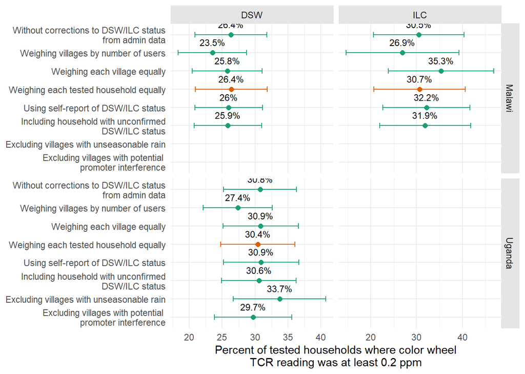

```r
plot_data <-
  list(
    "Weighing each tested household equally" = cl_village_noweights_country,
    "Weighing each village equally" = cl_village_vilweights,
    "Weighing villages by number of users" = cl_village_userweights,
    "Without corrections to DSW/ILC status\nfrom admin data" = cl_village_fo,
    "Using self-report of DSW/ILC status" = cl_village_self,
    "Including household with unconfirmed\nDSW/ILC status" = cl_village_all,
    "Excluding villages with unseasonable rain" = cl_village_rain,
    "Excluding villages with potential \npromoter interference" = cl_village_int
  ) %>%
    map(
      ~ .x %>%
        dplyr::filter(outcome == "disctcr_02") %>%
        select(country, wp_intervention, outcome, mean, ub, lb)
    ) %>%
    bind_rows(.id = "label") %>%
    mutate(
      across(
        c(mean, ub, lb),
        ~ . * 100
      ),
      main = (label == "Weighing each tested household equally")
  ) %>%
  dplyr::filter(wp_intervention != "Non-program")

plot_data %>%
  ggplot(
    aes(
      y = label,
      xmin = lb,
      xmax = ub,
      x = mean,
      label = round(mean, 1) %>% paste0("%"),
      color = main
    )
  ) +
  geom_errorbar(width = .3) +
  geom_point(size = 2) +
  geom_text(
    color = "black",
    size = 3,
    vjust = -1
  ) +
  facet_grid(
    country ~ wp_intervention,
    scales = "free_x"
  ) +
  scale_x_continuous(labels = ~ format(., big.mark = ",", scientific = FALSE)) +
  scale_fill_brewer(palette = "Dark2") +
  scale_color_brewer(palette = "Dark2") +
  theme +
  labs(
    y = NULL,
    x = "Percent of tested households where color wheel\nTCR reading was at least 0.2 ppm"
  )
```

#### 4.2.4.10 Save Plot

```r
ggplot2::ggsave(
  filename = "output/graphs/chlorine-vil.png",
  plot     = ggplot2::last_plot(),
  width    = 8,
  height   = 5,
  units    = "in",
  dpi      = 300
)
```

## 4.3 Table

### 4.3.1 By program

```r
obs <-
  users_village %>%
    group_by(
      country, wp_intervention
    ) %>%
    summarise(
      visited_villages = sum(hhs != 0),
      census = sum(hhs) %>% format(big.mark = ",")
    ) %>%
    mutate(
      name = "est"
    )

people <-
  people_per_country %>%
  left_join(
    wp_sample_sizes %>%
      group_by(country, wp_intervention) %>%
      summarise(pop = sum(pop_points))
  ) %>%
  mutate(
    across(
      c(total, lb, ub, pop),
      ~ . %>%
        round %>%
        format(big.mark = ",") %>%
        str_remove_all(" ")
    ),
    ci = paste0("(", lb, ", ", ub, ")")
  ) %>%
  select(
    country, wp_intervention, pop, est = total, ci
  ) %>%
  pivot_longer(
    cols = c(est, ci),
    values_to = "people"
  )

cl <-
  cl_village_noweights_country %>%
  mutate(
    across(
      c(mean, lb, ub),
      ~ (. * 100) %>%
        round(1) %>%
        str_remove_all(" ")
    ),
    ci = paste0("(", lb, ", ", ub, ")") ,
    hhs = hhs %>% format(big.mark = ",")
  ) %>%
  select(country, wp_intervention, outcome, villages, hhs, est = mean, ci) %>%
  pivot_wider(
    values_from = c(est, ci),
    names_from = outcome
  ) %>%
  pivot_longer(
    cols = ends_with("02"),
    names_pattern = "(.*)_disc(.*)_02",
    names_to = c("name", ".value")
  )

tab <-
  obs %>%
  full_join(people) %>%
  left_join(cl) %>%
  arrange(country, wp_intervention, desc(name)) %>%
  mutate(
    across(
      everything(),
      ~ as.character(.)
    ),
    across(
      -c(people, tcr, fcr),
      ~ case_when(
        name == "est" ~ .,
        TRUE ~ ""
      )
    )
  ) %>%
  ungroup %>%
  select(-c(name, country))

table <-
  kable(
    tab,
    format = "latex",
    escape = F,
    align = "c",
    booktabs = T,
    col.names = linebreak(
      c("Intervention", "\\#Vil", "\\#HH", "\\#Vil", "People using\nDSW/ILC\n(95\\% CI)", "\\#Vil", "\\#HH", "TCR\n(95\\% CI)", "FCR\n(95\\% CI)"),
      align = "c"
    ),
    caption = "Primary outcomes estimated using the village as the unit of reference",
    label = "headlines-vil"
  ) %>%
  kable_styling(latex_options = c("scale_down", "HOLD_position")) %>%
  pack_rows("Malawi", 1, 4) %>%
  pack_rows("Uganda", 5, 6) %>%
  add_header_above(
    c(
      " ",
      "Household census" = 2,
      "Country-level estimates" = 2,
      "Percent of color wheel readings ≥ 0.2 ppm" = 4
    )
  ) %>%
  add_header_above(c(" ", paste0("(", 1:8,")")), line = FALSE)

writeLines(
  table,
  "output/tables/headlines-vil.tex"
)
```

### 4.3.2 By program and sample group

```r
obs <-
  users_village %>%
    group_by(
      country, wp_intervention, sample_group
    ) %>%
    summarise(
      visited_villages = sum(hhs != 0),
      census = sum(hhs) %>% format(big.mark = ",")
    ) %>%
    mutate(
      name = "est"
    )

people <-
  people_per_group %>%
  left_join(
    wp_sample_sizes %>%
      group_by(country, wp_intervention, sample_group) %>%
      summarise(pop = sum(pop_points))
  ) %>%
  mutate(
    across(
      c(total, lb, ub, pop),
      ~ . %>%
        round %>%
        format(big.mark = ",") %>%
        str_remove_all(" ")
    ),
    ci = paste0("(", lb, ", ", ub, ")")
  ) %>%
  select(
    country, wp_intervention, sample_group, pop, est = total, ci
  ) %>%
  pivot_longer(
    cols = c(est, ci),
    values_to = "people"
  )

cl <-
  cl_village_noweights_samplegroup %>%
  mutate(
    across(
      c(mean, lb, ub),
      ~ (. * 100) %>%
        round(1) %>%
        str_remove_all(" ")
    ),
    ci = paste0("(", lb, ", ", ub, ")") ,
    hhs = hhs %>% format(big.mark = ",")
  ) %>%
  select(country, wp_intervention, sample_group, outcome, villages, hhs, est = mean, ci) %>%
  pivot_wider(
    values_from = c(est, ci),
    names_from = outcome
  ) %>%
  pivot_longer(
    cols = ends_with("02"),
    names_pattern = "(.*)_disc(.*)_02",
    names_to = c("name", ".value")
  )

tab <-
  obs %>%
  full_join(people) %>%
  left_join(cl) %>%
  arrange(country, wp_intervention, sample_group, desc(name)) %>%
  ungroup %>%
  mutate(
    across(
      everything(),
      ~ as.character(.)
    ),
    across(
      -c(people, tcr, fcr),
      ~ case_when(
        name == "est" ~ .,
        TRUE ~ ""
      )
    )
  ) %>%
  select(-c(name, country))

table <-
  kable(
    tab,
    format = "latex",
    escape = F,
    align = "c",
    booktabs = T,
    col.names = linebreak(
      c(" ", "Sample group", "\\#Vil", "\\#HH", "\\#Vil", "People using\nDSW/ILC\n(95\\% CI)", "\\#Vil", "\\#HH", "TCR\n(95\\% CI)", "FCR\n(95\\% CI)"),
      align = "c"
    ),
    caption = "Primary outcomes estimated using the village as the unit of reference",
    label = "headlines-vil-by-group"
  ) %>%
  kable_styling(latex_options = c("scale_down", "HOLD_position")) %>%
  pack_rows("Malawi", 1, 8) %>%
  pack_rows("Uganda", 9, 12) %>%
  add_header_above(
    c(
      " " = 2,
      "Household census" = 2,
      "Country-level estimates" = 2,
      "Percent of color wheel readings ≥ 0.2 ppm" = 4
    )
  ) %>%
  add_header_above(c(" ", " ", paste0("(", 1:8,")")), line = FALSE)

writeLines(
  table,
  "output/tables/headlines-vil-by-group.tex"
)
```